# Risk Factor Analysis

## Outcome Variable

**Outcome Variable:** haz

## Predictor Variables

**Intervention Variable:** perdiar24

**Adjustment Set:**

- arm
- sex
- meducyrs
- hhwealth_quart
- hfoodsec
- hdlvry
- W_birthwt
- W_birthlen
- W_nrooms
- month
- brthmon
- impfloor
- impsan
- safeh20
- delta_meducyrs
- delta_hhwealth_quart
- delta_hfoodsec
- delta_hdlvry
- delta_W_birthwt
- delta_W_birthlen
- delta_W_nrooms
- delta_month
- delta_brthmon
- delta_impfloor
- delta_impsan
- delta_safeh20

## Stratifying Variables

The analysis was stratified on these variable(s):

- agecat
- studyid
- country

## Data Summary

| agecat | studyid | country | perdiar24 | n_cell | n |
| --- | --- | --- | --- | --- | --- |
| Birth | ki0047075b-MAL-ED | BANGLADESH | (0%, 5%] | 146 | 257 |
| Birth | ki0047075b-MAL-ED | BANGLADESH | >5% | 89 | 257 |
| Birth | ki0047075b-MAL-ED | BANGLADESH | 0% | 22 | 257 |
| Birth | ki0047075b-MAL-ED | BRAZIL | (0%, 5%] | 81 | 191 |
| Birth | ki0047075b-MAL-ED | BRAZIL | >5% | 2 | 191 |
| Birth | ki0047075b-MAL-ED | BRAZIL | 0% | 108 | 191 |
| Birth | ki0047075b-MAL-ED | INDIA | (0%, 5%] | 156 | 206 |
| Birth | ki0047075b-MAL-ED | INDIA | >5% | 38 | 206 |
| Birth | ki0047075b-MAL-ED | INDIA | 0% | 12 | 206 |
| Birth | ki0047075b-MAL-ED | NEPAL | (0%, 5%] | 103 | 173 |
| Birth | ki0047075b-MAL-ED | NEPAL | >5% | 56 | 173 |
| Birth | ki0047075b-MAL-ED | NEPAL | 0% | 14 | 173 |
| Birth | ki0047075b-MAL-ED | PERU | (0%, 5%] | 109 | 287 |
| Birth | ki0047075b-MAL-ED | PERU | >5% | 151 | 287 |
| Birth | ki0047075b-MAL-ED | PERU | 0% | 27 | 287 |
| Birth | ki0047075b-MAL-ED | SOUTH AFRICA | (0%, 5%] | 154 | 252 |
| Birth | ki0047075b-MAL-ED | SOUTH AFRICA | >5% | 3 | 252 |
| Birth | ki0047075b-MAL-ED | SOUTH AFRICA | 0% | 95 | 252 |
| Birth | ki0047075b-MAL-ED | TANZANIA, UNITED REPUBLIC OF | (0%, 5%] | 90 | 123 |
| Birth | ki0047075b-MAL-ED | TANZANIA, UNITED REPUBLIC OF | >5% | 25 | 123 |
| Birth | ki0047075b-MAL-ED | TANZANIA, UNITED REPUBLIC OF | 0% | 8 | 123 |
| Birth | ki1000109-EE | PAKISTAN | (0%, 5%] | 2 | 2 |
| Birth | ki1000109-EE | PAKISTAN | >5% | 0 | 2 |
| Birth | ki1000109-EE | PAKISTAN | 0% | 0 | 2 |
| Birth | ki1000109-ResPak | PAKISTAN | (0%, 5%] | 2 | 6 |
| Birth | ki1000109-ResPak | PAKISTAN | >5% | 4 | 6 |
| Birth | ki1000109-ResPak | PAKISTAN | 0% | 0 | 6 |
| Birth | ki1017093-NIH-Birth | BANGLADESH | (0%, 5%] | 8 | 26 |
| Birth | ki1017093-NIH-Birth | BANGLADESH | >5% | 14 | 26 |
| Birth | ki1017093-NIH-Birth | BANGLADESH | 0% | 4 | 26 |

[output cut: 123 more lines]

The following strata were considered:

- agecat: 24 months, studyid: ki0047075b-MAL-ED, country: BANGLADESH
- agecat: 24 months, studyid: ki0047075b-MAL-ED, country: BRAZIL
- agecat: 24 months, studyid: ki0047075b-MAL-ED, country: INDIA
- agecat: 24 months, studyid: ki0047075b-MAL-ED, country: NEPAL
- agecat: 24 months, studyid: ki0047075b-MAL-ED, country: PERU
- agecat: 24 months, studyid: ki0047075b-MAL-ED, country: SOUTH AFRICA
- agecat: 24 months, studyid: ki0047075b-MAL-ED, country: TANZANIA, UNITED REPUBLIC OF
- agecat: 24 months, studyid: ki1017093-NIH-Birth, country: BANGLADESH
- agecat: 24 months, studyid: ki1017093b-PROVIDE, country: BANGLADESH
- agecat: 24 months, studyid: ki1017093c-NIH-Crypto, country: BANGLADESH
- agecat: 24 months, studyid: ki1114097-CMIN, country: BANGLADESH
- agecat: 24 months, studyid: ki1114097-CMIN, country: GUINEA-BISSAU
- agecat: 24 months, studyid: ki1114097-CMIN, country: PERU
- agecat: 24 months, studyid: ki1114097-CONTENT, country: PERU
- agecat: 24 months, studyid: kiGH5241-JiVitA-4, country: BANGLADESH
- agecat: 6 months, studyid: ki0047075b-MAL-ED, country: BANGLADESH
- agecat: 6 months, studyid: ki0047075b-MAL-ED, country: BRAZIL
- agecat: 6 months, studyid: ki0047075b-MAL-ED, country: INDIA
- agecat: 6 months, studyid: ki0047075b-MAL-ED, country: NEPAL
- agecat: 6 months, studyid: ki0047075b-MAL-ED, country: PERU
- agecat: 6 months, studyid: ki0047075b-MAL-ED, country: SOUTH AFRICA
- agecat: 6 months, studyid: ki0047075b-MAL-ED, country: TANZANIA, UNITED REPUBLIC OF
- agecat: 6 months, studyid: ki1000109-EE, country: PAKISTAN
- agecat: 6 months, studyid: ki1000109-ResPak, country: PAKISTAN
- agecat: 6 months, studyid: ki1000304b-SAS-FoodSuppl, country: INDIA
- agecat: 6 months, studyid: ki1017093-NIH-Birth, country: BANGLADESH
- agecat: 6 months, studyid: ki1017093b-PROVIDE, country: BANGLADESH
- agecat: 6 months, studyid: ki1017093c-NIH-Crypto, country: BANGLADESH
- agecat: 6 months, studyid: ki1112895-Guatemala BSC, country: GUATEMALA
- agecat: 6 months, studyid: ki1114097-CMIN, country: BANGLADESH
- agecat: 6 months, studyid: ki1114097-CMIN, country: BRAZIL
- agecat: 6 months, studyid: ki1114097-CMIN, country: GUINEA-BISSAU
- agecat: 6 months, studyid: ki1114097-CMIN, country: PERU
- agecat: 6 months, studyid: ki1114097-CONTENT, country: PERU
- agecat: 6 months, studyid: kiGH5241-JiVitA-4, country: BANGLADESH
- agecat: Birth, studyid: ki0047075b-MAL-ED, country: BANGLADESH
- agecat: Birth, studyid: ki0047075b-MAL-ED, country: BRAZIL
- agecat: Birth, studyid: ki0047075b-MAL-ED, country: INDIA
- agecat: Birth, studyid: ki0047075b-MAL-ED, country: NEPAL
- agecat: Birth, studyid: ki0047075b-MAL-ED, country: PERU
- agecat: Birth, studyid: ki0047075b-MAL-ED, country: SOUTH AFRICA
- agecat: Birth, studyid: ki0047075b-MAL-ED, country: TANZANIA, UNITED REPUBLIC OF
- agecat: Birth, studyid: ki1000109-EE, country: PAKISTAN
- agecat: Birth, studyid: ki1000109-ResPak, country: PAKISTAN
- agecat: Birth, studyid: ki1017093-NIH-Birth, country: BANGLADESH
- agecat: Birth, studyid: ki1017093c-NIH-Crypto, country: BANGLADESH
- agecat: Birth, studyid: ki1114097-CMIN, country: BANGLADESH
- agecat: Birth, studyid: ki1114097-CMIN, country: BRAZIL
- agecat: Birth, studyid: ki1114097-CMIN, country: PERU
- agecat: Birth, studyid: ki1114097-CONTENT, country: PERU
- agecat: Birth, studyid: kiGH5241-JiVitA-4, country: BANGLADESH

### Dropped Strata

Some strata were dropped due to rare outcomes:

- agecat: Birth, studyid: ki0047075b-MAL-ED, country: BRAZIL
- agecat: Birth, studyid: ki0047075b-MAL-ED, country: SOUTH AFRICA
- agecat: Birth, studyid: ki1000109-EE, country: PAKISTAN
- agecat: Birth, studyid: ki1000109-ResPak, country: PAKISTAN
- agecat: Birth, studyid: ki1017093-NIH-Birth, country: BANGLADESH
- agecat: Birth, studyid: ki1114097-CMIN, country: BANGLADESH
- agecat: Birth, studyid: ki1114097-CMIN, country: BRAZIL
- agecat: Birth, studyid: ki1114097-CMIN, country: PERU
- agecat: Birth, studyid: ki1114097-CONTENT, country: PERU
- agecat: 6 months, studyid: ki0047075b-MAL-ED, country: BRAZIL
- agecat: 6 months, studyid: ki0047075b-MAL-ED, country: INDIA
- agecat: 6 months, studyid: ki0047075b-MAL-ED, country: SOUTH AFRICA
- agecat: 6 months, studyid: ki1114097-CMIN, country: BANGLADESH
- agecat: 6 months, studyid: ki1114097-CMIN, country: BRAZIL
- agecat: 24 months, studyid: ki0047075b-MAL-ED, country: BRAZIL
- agecat: 24 months, studyid: ki0047075b-MAL-ED, country: INDIA
- agecat: 24 months, studyid: ki0047075b-MAL-ED, country: PERU
- agecat: 24 months, studyid: ki0047075b-MAL-ED, country: SOUTH AFRICA
- agecat: 24 months, studyid: ki1114097-CMIN, country: BANGLADESH
- agecat: 24 months, studyid: ki1114097-CONTENT, country: PERU

## Methods Detail

We’re interested in the causal parameters $E[Y_a]$ for all values of $a \in \mathcal{A}$. These parameters represent the mean outcome if, possibly contrary to fact, we intervened to set all units to have $A=a$. Under the randomization and positivity assumptions, these are identified by the statistical parameters $\psi_a=E_W[E_{Y|A,W}(Y|A=a,W)]$. In addition, we’re interested in the mean of $Y$, $E[Y]$ under no intervention (the observed mean). We will estimate these parameters by using SuperLearner to fit the relevant likelihood factors – $E_{Y|A,W}(Y|A=a,W)$ and $p(A=a|W)$, and then updating our likelihood fit using a joint TMLE.

For unadjusted analyses ($W=\{\}$), initial likelihoods were estimated using Lrnr_glm to estimate the simple $E(Y|A)$ and Lrnr_mean to estimate $p(A)$. For adjusted analyses, a small library containing Lrnr_glmnet, Lrnr_xgboost, and Lrnr_mean was used.

Having estimated these parameters, we will then use the delta method to estimate relative risks and attributable risks relative to a prespecified baseline level of $A$.

# Results Detail

## Results Plots

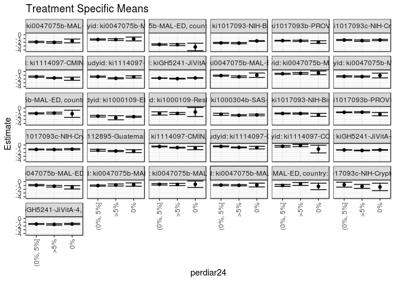

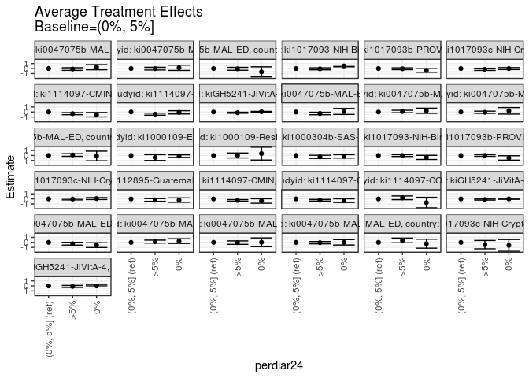

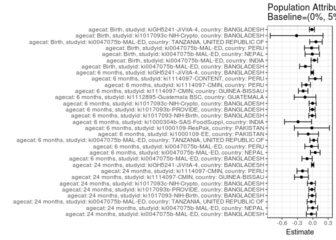

## Results Table

### Parameter: TSM

| agecat | studyid | country | intervention_level | baseline_level | estimate | ci_lower | ci_upper |
| --- | --- | --- | --- | --- | --- | --- | --- |
| Birth | ki0047075b-MAL-ED | BANGLADESH | (0%, 5%] | NA | -0.9395770 | -1.0970637 | -0.7820902 |
| Birth | ki0047075b-MAL-ED | BANGLADESH | >5% | NA | -1.1988780 | -1.4218947 | -0.9758612 |
| Birth | ki0047075b-MAL-ED | BANGLADESH | 0% | NA | -1.4831472 | -1.9340481 | -1.0322464 |
| Birth | ki0047075b-MAL-ED | INDIA | (0%, 5%] | NA | -1.0414106 | -1.2019739 | -0.8808473 |
| Birth | ki0047075b-MAL-ED | INDIA | >5% | NA | -0.8841978 | -1.1504072 | -0.6179884 |
| Birth | ki0047075b-MAL-ED | INDIA | 0% | NA | -0.7807258 | -1.2272203 | -0.3342312 |
| Birth | ki0047075b-MAL-ED | NEPAL | (0%, 5%] | NA | -0.6984681 | -0.8898813 | -0.5070549 |
| Birth | ki0047075b-MAL-ED | NEPAL | >5% | NA | -0.7445614 | -1.0273660 | -0.4617567 |
| Birth | ki0047075b-MAL-ED | NEPAL | 0% | NA | -0.6817643 | -1.5345393 | 0.1710106 |
| Birth | ki0047075b-MAL-ED | PERU | (0%, 5%] | NA | -0.9097820 | -1.0820940 | -0.7374701 |
| Birth | ki0047075b-MAL-ED | PERU | >5% | NA | -0.9612810 | -1.1185796 | -0.8039824 |
| Birth | ki0047075b-MAL-ED | PERU | 0% | NA | -0.8919033 | -1.4022121 | -0.3815945 |
| Birth | ki0047075b-MAL-ED | TANZANIA, UNITED REPUBLIC OF | (0%, 5%] | NA | -0.9958889 | -1.2515539 | -0.7402239 |
| Birth | ki0047075b-MAL-ED | TANZANIA, UNITED REPUBLIC OF | >5% | NA | -0.6080000 | -0.9936631 | -0.2223369 |
| Birth | ki0047075b-MAL-ED | TANZANIA, UNITED REPUBLIC OF | 0% | NA | -1.2537500 | -2.1121999 | -0.3953001 |
| Birth | ki1017093c-NIH-Crypto | BANGLADESH | (0%, 5%] | NA | -0.7940000 | -1.4367037 | -0.1512963 |
| Birth | ki1017093c-NIH-Crypto | BANGLADESH | >5% | NA | -1.2436364 | -1.7669142 | -0.7203586 |
| Birth | ki1017093c-NIH-Crypto | BANGLADESH | 0% | NA | -1.3916667 | -2.3744611 | -0.4088722 |
| Birth | kiGH5241-JiVitA-4 | BANGLADESH | (0%, 5%] | NA | -1.4801533 | -1.5781048 | -1.3822018 |
| Birth | kiGH5241-JiVitA-4 | BANGLADESH | >5% | NA | -1.5832733 | -1.7668149 | -1.3997317 |
| Birth | kiGH5241-JiVitA-4 | BANGLADESH | 0% | NA | -1.4808145 | -1.6366036 | -1.3250254 |
| 6 months | ki0047075b-MAL-ED | BANGLADESH | (0%, 5%] | NA | -1.0936150 | -1.2373445 | -0.9498855 |
| 6 months | ki0047075b-MAL-ED | BANGLADESH | >5% | NA | -1.3909140 | -1.5928426 | -1.1889854 |
| 6 months | ki0047075b-MAL-ED | BANGLADESH | 0% | NA | -0.9866667 | -1.5612360 | -0.4120973 |
| 6 months | ki0047075b-MAL-ED | NEPAL | (0%, 5%] | NA | -0.6089052 | -0.7474358 | -0.4703745 |
| 6 months | ki0047075b-MAL-ED | NEPAL | >5% | NA | -0.5091818 | -0.7163136 | -0.3020499 |
| 6 months | ki0047075b-MAL-ED | NEPAL | 0% | NA | -0.3672830 | -0.8588544 | 0.1242884 |
| 6 months | ki0047075b-MAL-ED | PERU | (0%, 5%] | NA | -1.3017584 | -1.4646943 | -1.1388225 |
| 6 months | ki0047075b-MAL-ED | PERU | >5% | NA | -1.3556369 | -1.5032709 | -1.2080030 |
| 6 months | ki0047075b-MAL-ED | PERU | 0% | NA | -1.0700000 | -1.6970711 | -0.4429289 |

[output cut: 63 more lines]

### Parameter: E(Y)

| agecat | studyid | country | intervention_level | baseline_level | estimate | ci_lower | ci_upper |
| --- | --- | --- | --- | --- | --- | --- | --- |
| Birth | ki0047075b-MAL-ED | BANGLADESH | NA | NA | -1.0843969 | -1.2100768 | -0.9587169 |
| Birth | ki0047075b-MAL-ED | INDIA | NA | NA | -1.0106311 | -1.1499962 | -0.8712660 |
| Birth | ki0047075b-MAL-ED | NEPAL | NA | NA | -0.7089017 | -0.8656064 | -0.5521971 |
| Birth | ki0047075b-MAL-ED | PERU | NA | NA | -0.9322300 | -1.0461262 | -0.8183337 |
| Birth | ki0047075b-MAL-ED | TANZANIA, UNITED REPUBLIC OF | NA | NA | -0.9338211 | -1.1465079 | -0.7211344 |
| Birth | ki1017093c-NIH-Crypto | BANGLADESH | NA | NA | -1.1100000 | -1.5086894 | -0.7113106 |
| Birth | kiGH5241-JiVitA-4 | BANGLADESH | NA | NA | -1.4976642 | -1.5817349 | -1.4135935 |
| 6 months | ki0047075b-MAL-ED | BANGLADESH | NA | NA | -1.2056777 | -1.3231497 | -1.0882058 |
| 6 months | ki0047075b-MAL-ED | NEPAL | NA | NA | -0.5610593 | -0.6737915 | -0.4483272 |
| 6 months | ki0047075b-MAL-ED | PERU | NA | NA | -1.3268010 | -1.4351217 | -1.2184802 |
| 6 months | ki0047075b-MAL-ED | TANZANIA, UNITED REPUBLIC OF | NA | NA | -1.3601215 | -1.4821830 | -1.2380600 |
| 6 months | ki1000109-EE | PAKISTAN | NA | NA | -2.2004704 | -2.3234073 | -2.0775336 |
| 6 months | ki1000109-ResPak | PAKISTAN | NA | NA | -1.4029220 | -1.6085859 | -1.1972581 |
| 6 months | ki1000304b-SAS-FoodSuppl | INDIA | NA | NA | -1.8986842 | -2.0118892 | -1.7854792 |
| 6 months | ki1017093-NIH-Birth | BANGLADESH | NA | NA | -1.4073821 | -1.4960598 | -1.3187043 |
| 6 months | ki1017093b-PROVIDE | BANGLADESH | NA | NA | -1.0871041 | -1.1635539 | -1.0106543 |
| 6 months | ki1017093c-NIH-Crypto | BANGLADESH | NA | NA | -1.1986783 | -1.2700937 | -1.1272630 |
| 6 months | ki1112895-Guatemala BSC | GUATEMALA | NA | NA | -1.5619008 | -1.6727702 | -1.4510313 |
| 6 months | ki1114097-CMIN | GUINEA-BISSAU | NA | NA | -0.6003317 | -0.6767125 | -0.5239510 |
| 6 months | ki1114097-CMIN | PERU | NA | NA | -0.5132548 | -0.5926717 | -0.4338380 |
| 6 months | ki1114097-CONTENT | PERU | NA | NA | -0.3139217 | -0.4868486 | -0.1409948 |
| 6 months | kiGH5241-JiVitA-4 | BANGLADESH | NA | NA | -1.3447940 | -1.3820261 | -1.3075620 |
| 24 months | ki0047075b-MAL-ED | BANGLADESH | NA | NA | -1.9431132 | -2.0691678 | -1.8170586 |
| 24 months | ki0047075b-MAL-ED | NEPAL | NA | NA | -1.2752193 | -1.3954783 | -1.1549603 |
| 24 months | ki0047075b-MAL-ED | TANZANIA, UNITED REPUBLIC OF | NA | NA | -2.6058879 | -2.7403043 | -2.4714714 |
| 24 months | ki1017093-NIH-Birth | BANGLADESH | NA | NA | -2.1807945 | -2.2835902 | -2.0779987 |
| 24 months | ki1017093b-PROVIDE | BANGLADESH | NA | NA | -1.5861179 | -1.6693668 | -1.5028689 |
| 24 months | ki1017093c-NIH-Crypto | BANGLADESH | NA | NA | -1.4295331 | -1.5127726 | -1.3462935 |
| 24 months | ki1114097-CMIN | GUINEA-BISSAU | NA | NA | -1.5996561 | -1.6995642 | -1.4997481 |
| 24 months | ki1114097-CMIN | PERU | NA | NA | -1.5759624 | -1.6729826 | -1.4789423 |
| 24 months | kiGH5241-JiVitA-4 | BANGLADESH | NA | NA | -1.7582681 | -1.7937283 | -1.7228079 |

### Parameter: ATE

| agecat | studyid | country | intervention_level | baseline_level | estimate | ci_lower | ci_upper |
| --- | --- | --- | --- | --- | --- | --- | --- |
| Birth | ki0047075b-MAL-ED | BANGLADESH | (0%, 5%] | (0%, 5%] | 0.0000000 | 0.0000000 | 0.0000000 |
| Birth | ki0047075b-MAL-ED | BANGLADESH | >5% | (0%, 5%] | -0.2593010 | -0.5330981 | 0.0144961 |
| Birth | ki0047075b-MAL-ED | BANGLADESH | 0% | (0%, 5%] | -0.5435703 | -1.0209429 | -0.0661977 |
| Birth | ki0047075b-MAL-ED | INDIA | (0%, 5%] | (0%, 5%] | 0.0000000 | 0.0000000 | 0.0000000 |
| Birth | ki0047075b-MAL-ED | INDIA | >5% | (0%, 5%] | 0.1572128 | -0.1395041 | 0.4539297 |
| Birth | ki0047075b-MAL-ED | INDIA | 0% | (0%, 5%] | 0.2606848 | -0.2057851 | 0.7271547 |
| Birth | ki0047075b-MAL-ED | NEPAL | (0%, 5%] | (0%, 5%] | 0.0000000 | 0.0000000 | 0.0000000 |
| Birth | ki0047075b-MAL-ED | NEPAL | >5% | (0%, 5%] | -0.0460932 | -0.3881184 | 0.2959320 |
| Birth | ki0047075b-MAL-ED | NEPAL | 0% | (0%, 5%] | 0.0167038 | -0.8573992 | 0.8908068 |
| Birth | ki0047075b-MAL-ED | PERU | (0%, 5%] | (0%, 5%] | 0.0000000 | 0.0000000 | 0.0000000 |
| Birth | ki0047075b-MAL-ED | PERU | >5% | (0%, 5%] | -0.0514989 | -0.2817559 | 0.1787580 |
| Birth | ki0047075b-MAL-ED | PERU | 0% | (0%, 5%] | 0.0178787 | -0.5189490 | 0.5547065 |
| Birth | ki0047075b-MAL-ED | TANZANIA, UNITED REPUBLIC OF | (0%, 5%] | (0%, 5%] | 0.0000000 | 0.0000000 | 0.0000000 |
| Birth | ki0047075b-MAL-ED | TANZANIA, UNITED REPUBLIC OF | >5% | (0%, 5%] | 0.3878889 | -0.0748212 | 0.8505990 |
| Birth | ki0047075b-MAL-ED | TANZANIA, UNITED REPUBLIC OF | 0% | (0%, 5%] | -0.2578611 | -1.1535736 | 0.6378513 |
| Birth | ki1017093c-NIH-Crypto | BANGLADESH | (0%, 5%] | (0%, 5%] | 0.0000000 | 0.0000000 | 0.0000000 |
| Birth | ki1017093c-NIH-Crypto | BANGLADESH | >5% | (0%, 5%] | -0.4496364 | -1.2784233 | 0.3791505 |
| Birth | ki1017093c-NIH-Crypto | BANGLADESH | 0% | (0%, 5%] | -0.5976667 | -1.7719550 | 0.5766216 |
| Birth | kiGH5241-JiVitA-4 | BANGLADESH | (0%, 5%] | (0%, 5%] | 0.0000000 | 0.0000000 | 0.0000000 |
| Birth | kiGH5241-JiVitA-4 | BANGLADESH | >5% | (0%, 5%] | -0.1031200 | -0.3026235 | 0.0963835 |
| Birth | kiGH5241-JiVitA-4 | BANGLADESH | 0% | (0%, 5%] | -0.0006612 | -0.1706876 | 0.1693653 |
| 6 months | ki0047075b-MAL-ED | BANGLADESH | (0%, 5%] | (0%, 5%] | 0.0000000 | 0.0000000 | 0.0000000 |
| 6 months | ki0047075b-MAL-ED | BANGLADESH | >5% | (0%, 5%] | -0.2972990 | -0.5451564 | -0.0494415 |
| 6 months | ki0047075b-MAL-ED | BANGLADESH | 0% | (0%, 5%] | 0.1069484 | -0.4853253 | 0.6992220 |
| 6 months | ki0047075b-MAL-ED | NEPAL | (0%, 5%] | (0%, 5%] | 0.0000000 | 0.0000000 | 0.0000000 |
| 6 months | ki0047075b-MAL-ED | NEPAL | >5% | (0%, 5%] | 0.0997234 | -0.1497149 | 0.3491617 |
| 6 months | ki0047075b-MAL-ED | NEPAL | 0% | (0%, 5%] | 0.2416222 | -0.2691363 | 0.7523806 |
| 6 months | ki0047075b-MAL-ED | PERU | (0%, 5%] | (0%, 5%] | 0.0000000 | 0.0000000 | 0.0000000 |
| 6 months | ki0047075b-MAL-ED | PERU | >5% | (0%, 5%] | -0.0538785 | -0.2737510 | 0.1659939 |
| 6 months | ki0047075b-MAL-ED | PERU | 0% | (0%, 5%] | 0.2317584 | -0.4161353 | 0.8796522 |

[output cut: 63 more lines]

### Parameter: PAR

| agecat | studyid | country | intervention_level | baseline_level | estimate | ci_lower | ci_upper |
| --- | --- | --- | --- | --- | --- | --- | --- |
| Birth | ki0047075b-MAL-ED | BANGLADESH | (0%, 5%] | NA | -0.1448199 | -0.2571080 | -0.0325318 |
| Birth | ki0047075b-MAL-ED | INDIA | (0%, 5%] | NA | 0.0307795 | -0.0331411 | 0.0947001 |
| Birth | ki0047075b-MAL-ED | NEPAL | (0%, 5%] | NA | -0.0104336 | -0.1511196 | 0.1302524 |
| Birth | ki0047075b-MAL-ED | PERU | (0%, 5%] | NA | -0.0224479 | -0.1627199 | 0.1178241 |
| Birth | ki0047075b-MAL-ED | TANZANIA, UNITED REPUBLIC OF | (0%, 5%] | NA | 0.0620678 | -0.0601809 | 0.1843164 |
| Birth | ki1017093c-NIH-Crypto | BANGLADESH | (0%, 5%] | NA | -0.3160000 | -0.8317954 | 0.1997954 |
| Birth | kiGH5241-JiVitA-4 | BANGLADESH | (0%, 5%] | NA | -0.0175109 | -0.0655536 | 0.0305318 |
| 6 months | ki0047075b-MAL-ED | BANGLADESH | (0%, 5%] | NA | -0.1120627 | -0.2126299 | -0.0114955 |
| 6 months | ki0047075b-MAL-ED | NEPAL | (0%, 5%] | NA | 0.0478459 | -0.0471711 | 0.1428628 |
| 6 months | ki0047075b-MAL-ED | PERU | (0%, 5%] | NA | -0.0250426 | -0.1557403 | 0.1056552 |
| 6 months | ki0047075b-MAL-ED | TANZANIA, UNITED REPUBLIC OF | (0%, 5%] | NA | 0.0194077 | -0.0571336 | 0.0959491 |
| 6 months | ki1000109-EE | PAKISTAN | (0%, 5%] | NA | -0.0902379 | -0.2914149 | 0.1109392 |
| 6 months | ki1000109-ResPak | PAKISTAN | (0%, 5%] | NA | -0.0182508 | -0.3606209 | 0.3241192 |
| 6 months | ki1000304b-SAS-FoodSuppl | INDIA | (0%, 5%] | NA | -0.2883290 | -0.5516426 | -0.0250154 |
| 6 months | ki1017093-NIH-Birth | BANGLADESH | (0%, 5%] | NA | -0.0114665 | -0.0778183 | 0.0548852 |
| 6 months | ki1017093b-PROVIDE | BANGLADESH | (0%, 5%] | NA | -0.0082968 | -0.0613837 | 0.0447901 |
| 6 months | ki1017093c-NIH-Crypto | BANGLADESH | (0%, 5%] | NA | -0.0037271 | -0.0724166 | 0.0649623 |
| 6 months | ki1112895-Guatemala BSC | GUATEMALA | (0%, 5%] | NA | -0.1510269 | -0.3618604 | 0.0598067 |
| 6 months | ki1114097-CMIN | GUINEA-BISSAU | (0%, 5%] | NA | -0.1879239 | -0.2798772 | -0.0959706 |
| 6 months | ki1114097-CMIN | PERU | (0%, 5%] | NA | -0.1305722 | -0.2154420 | -0.0457025 |
| 6 months | ki1114097-CONTENT | PERU | (0%, 5%] | NA | 0.0471182 | -0.0766943 | 0.1709307 |
| 6 months | kiGH5241-JiVitA-4 | BANGLADESH | (0%, 5%] | NA | -0.0106244 | -0.0363675 | 0.0151187 |
| 24 months | ki0047075b-MAL-ED | BANGLADESH | (0%, 5%] | NA | -0.0276132 | -0.1263746 | 0.0711482 |
| 24 months | ki0047075b-MAL-ED | NEPAL | (0%, 5%] | NA | -0.0022780 | -0.1002234 | 0.0956675 |
| 24 months | ki0047075b-MAL-ED | TANZANIA, UNITED REPUBLIC OF | (0%, 5%] | NA | -0.0307276 | -0.1105452 | 0.0490900 |
| 24 months | ki1017093-NIH-Birth | BANGLADESH | (0%, 5%] | NA | -0.0123984 | -0.0836931 | 0.0588962 |
| 24 months | ki1017093b-PROVIDE | BANGLADESH | (0%, 5%] | NA | -0.0179453 | -0.0764431 | 0.0405525 |
| 24 months | ki1017093c-NIH-Crypto | BANGLADESH | (0%, 5%] | NA | -0.0267410 | -0.1044929 | 0.0510108 |
| 24 months | ki1114097-CMIN | GUINEA-BISSAU | (0%, 5%] | NA | -0.2218060 | -0.3570394 | -0.0865725 |
| 24 months | ki1114097-CMIN | PERU | (0%, 5%] | NA | -0.2017911 | -0.3090450 | -0.0945373 |
| 24 months | kiGH5241-JiVitA-4 | BANGLADESH | (0%, 5%] | NA | -0.0028406 | -0.0260597 | 0.0203785 |